# Upsupervised Techniques and PCA on satellite images

## Principal Component Analysis (PCA)

Principal Component Analysis (PCA) is a popular dimensionality reduction technique used in Machine Learning applications. PCA condenses information from a large set of variables into fewer variables by applying some sort of transformation onto them. The transformation is applied in such a way that linearly correlated variables get transformed into uncorrelated variables. Correlation tells us that there is a redundancy of information and if this redundancy can be reduced, then information can be compressed. For example, if there are two variables in the variable set which are highly correlated, then, we are not gaining any extra information by retaining both the variables because one can be nearly expressed as the linear combination of the other. In such cases, PCA transfers the variance of the second variable onto the first variable by translation and rotation of original axes and projecting data onto new axes. The direction of projection is determined using eigenvalues and eigenvectors. So, the first few transformed features (termed as Principal Components) are rich in information, whereas the last features contain mostly noise with negligible information in them. This transferability allows us to retain the first few principal components, thus reducing the number of variables significantly with minimal loss of information.

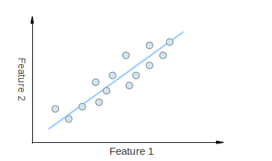

Consider that you have a set of 2D points as it is shown in the figure above. Each dimension corresponds to a feature you are interested in. Here some could argue that the points are set in a random order. However, if you have a better look you will see that there is a linear pattern (indicated by the blue line) which is hard to dismiss. A key point of PCA is the Dimensionality Reduction. Dimensionality Reduction is the process of reducing the number of the dimensions of the given dataset. For example, in the above case it is possible to approximate the set of points to a single line and therefore, reduce the dimensionality of the given points from 2D to 1D.

Moreover, you could also see that the points vary the most along the blue line, more than they vary along the Feature 1 or Feature 2 axes. This means that if you know the position of a point along the blue line you have more information about the point than if you only knew where it was on Feature 1 axis or Feature 2 axis.

Hence, PCA allows us to find the direction along which our data varies the most. In fact, the result of running PCA on the set of points in the diagram consist of 2 vectors called eigenvectors which are the principal components of the data set.

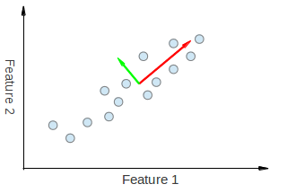

The size of each eigenvector is encoded in the corresponding eigenvalue and indicates how much the data vary along the principal component. The beginning of the eigenvectors is the center of all points in the data set. Applying PCA to N-dimensional data set yields N N-dimensional eigenvectors, N eigenvalues and 1 N-dimensional center point.

### PCA on Remote Sensing Imagery

Adjacent bands in a multi- or hyperspectral remotely sensed image are generally correlated. Multiband visible/NIR images of vegetated areas exhibit negative correlations between the NIR and visible red bands and positive correlations among the visible bands because the spectral reflectance characteristics of vegetation are such that as the vigour or greenness of the vegetation increases the red reflectance diminishes and the NIR reflectance increases. The presence of correlations among the bands of a multispectral image implies that there is redundancy in the data. Some information is being repeated. It is the repetition of information between the bands that is reflected in their intercorrelations.

Let's start by installing the necessary packages:

```python
!pip install rasterio
```

```
Downloading rasterio-1.3.11-cp310-cp310-manylinux_2_17_x86_64.manylinux2014_x86_64.whl (21.7 MB)
   ━━━━━━━━━━━━━━━━━━━━━━━━━━━━━━━━━━━━━━━━ 21.7/21.7 MB 24.6 MB/s eta 0:00:00
Downloading snuggs-1.4.7-py3-none-any.whl (5.4 kB)
Downloading affine-2.4.0-py3-none-any.whl (15 kB)
```

```python
import ee
ee.Authenticate()
ee.Initialize(project='my-project-1527255156007')
```

```python
from google.colab import drive
drive.mount('/content/drive')
```

```python
import folium
from folium import plugins
from IPython.display import Image
import rasterio
import numpy as np
from matplotlib import pyplot as plt
import cv2
from matplotlib import cm
from collections import Counter
from skimage.transform import resize
from sklearn.cluster import KMeans
```

For this example we will use the image used in the last class:

```python
path_barcelona = '/content/drive/MyDrive/Datasets_CV/Barcelona.tif'
```

```python
with rasterio.open(path_barcelona) as src:
    im = src.read()
```

```python
im = im.transpose([1,2,0])
```

```python
img = im*2*255
```

```python
img = img.astype('uint8')
```

```python
red = img[:,:,2]
green = img[:,:,1]
blue = img[:,:,0]
```

And plot the RGB image:

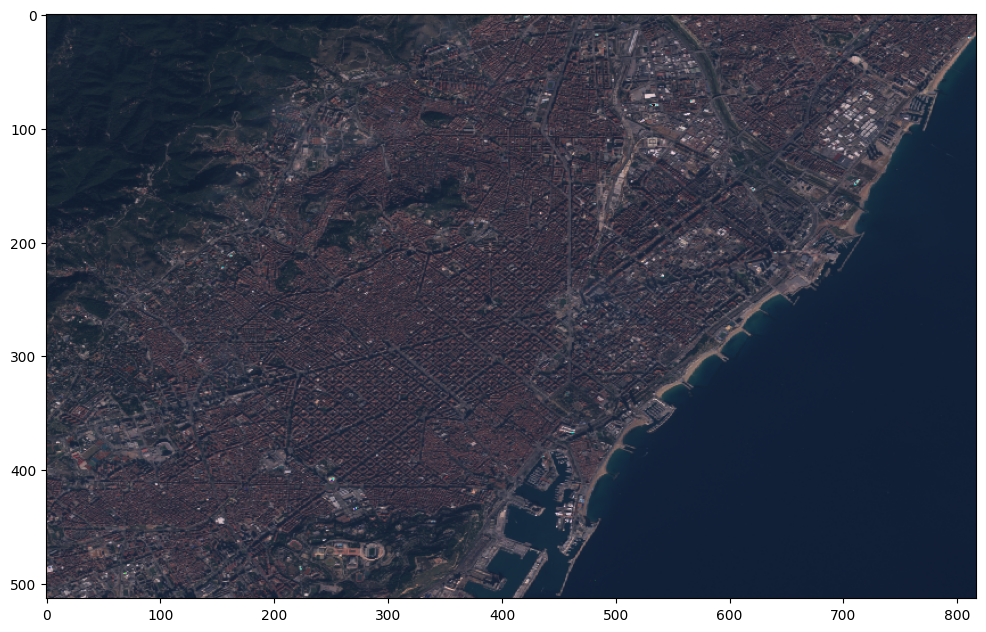

```python
rgb = np.dstack((red, green, blue))
plt.figure(figsize=[12,12])
plt.imshow(rgb)
```

Before applying the PCA, it is necessary to resize the image by flattening the column and row dimensions into one:

```python
pca_img = img.reshape((img.shape[0]*img.shape[1],img.shape[2]))
```

We import the SKlearn PCA:

```python
from sklearn.decomposition import PCA
import pandas as pd
```

As we have 5 bands, let's set the number of components to 5:

```python
pca = PCA(n_components = 5)
```

and then we perform the transformation:

```python
principalComponents = pca.fit_transform(pca_img)
```

Let's see how much variance each component retains:

```python
exp_variance = pca.explained_variance_ratio_
```

```python
print(np.round(exp_variance,3))
```

```
[0.84  0.129 0.023 0.007 0.001]
```

Let's build a graph of components by variance and components by accumulated variance:

```python
comp = np.arange(1,6)
```

```python
df_variance  = pd.Series(exp_variance,name='explained variance')
```

```python
df_cum_variance  = pd.Series(np.cumsum(exp_variance),name='cumulative explained variance')
```

```python
df_comp = pd.Series(comp, name='Number of components')
```

```python
df = pd.concat([df_variance, df_cum_variance, df_comp], axis=1)
```

```python
import seaborn as sns
sns.set_theme(style="darkgrid")
from matplotlib import rcParams


rcParams['figure.figsize'] = 8,6
```

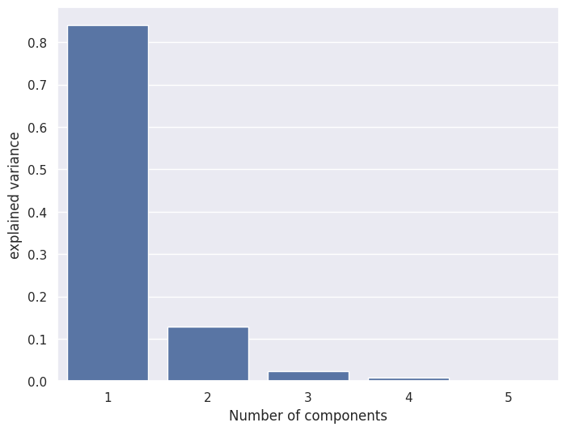

```python
ax = sns.barplot(x="Number of components", y="explained variance", data=df)
```

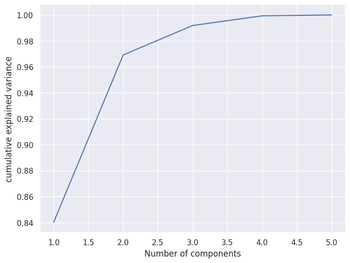

```python
ax = sns.lineplot(data=df, x="Number of components", y="cumulative explained variance")
```

Now we can plot each component separately:

```python
principalComponents = principalComponents.reshape(img.shape[0],img.shape[1],img.shape[2])
```

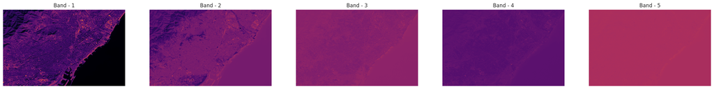

```python
fig = plt.figure(figsize = (30, 20))

for i in range(img.shape[2]):
    fig.add_subplot(1,img.shape[2], i+1)
    plt.imshow(principalComponents[:,:,i], cmap='inferno')
    plt.axis('off')
    plt.title(f'Band - '+ str(i+1))
```

We can also plot an image of the first three components as an RGB image:

```python
PCA_nomr = cv2.normalize(principalComponents, np.zeros(principalComponents.shape),0,255 ,cv2.NORM_MINMAX)
```

```python
PCA_nomr = PCA_nomr.astype('uint8')
```

```
(-0.5, 816.5, 512.5, -0.5)
```

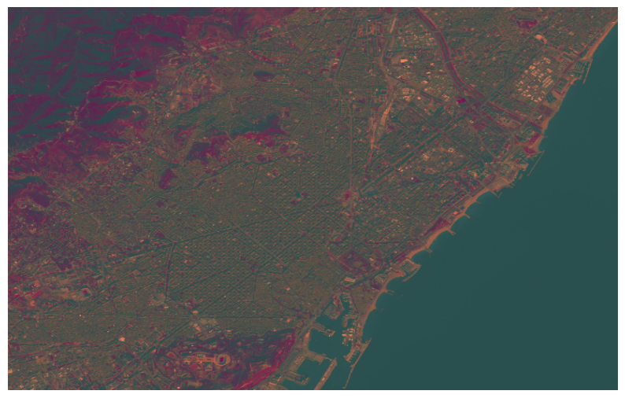

```python
plt.figure(figsize = (10, 10))
plt.imshow(PCA_nomr[:,:,0:3])
plt.axis('off')
```

## Clustering

Cluster analysis or clustering is the task of grouping a set of objects in such a way that objects in the same group (called a cluster) are more similar (in some sense) to each other than to those in other groups (clusters).

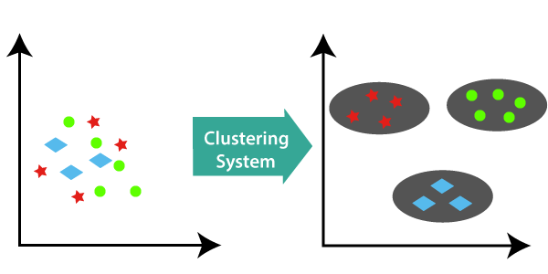

Types of Clustering:

Types of clustering algorithms:

Since the task of clustering is subjective, the means that can be used for achieving this goal are plenty. Every methodology follows a different set of rules for defining the ‘similarity’ among data points. In fact, there are more than 100 clustering algorithms known. But few of the algorithms are used popularly, let’s look at them in detail:

- Connectivity models: As the name suggests, these models are based on the notion that the data points closer in data space exhibit more similarity to each other than the data points lying farther away. These models can follow two approaches. In the first approach, they start with classifying all data points into separate clusters & then aggregating them as the distance decreases. In the second approach, all data points are classified as a single cluster and then partitioned as the distance increases. Also, the choice of distance function is subjective. These models are very easy to interpret but lacks scalability for handling big datasets. Examples of these models are hierarchical clustering algorithm and its variants.
- Centroid models: These are iterative clustering algorithms in which the notion of similarity is derived by the closeness of a data point to the centroid of the clusters. K-Means clustering algorithm is a popular algorithm that falls into this category. In these models, the no. of clusters required at the end have to be mentioned beforehand, which makes it important to have prior knowledge of the dataset. These models run iteratively to find the local optima.
- Distribution models: These clustering models are based on the notion of how probable is it that all data points in the cluster belong to the same distribution (For example: Normal, Gaussian). These models often suffer from overfitting. A popular example of these models is Expectation-maximization algorithm which uses multivariate normal distributions.
- Density Models: These models search the data space for areas of varied density of data points in the data space. It isolates various different density regions and assign the data points within these regions in the same cluster. Popular examples of density models are DBSCAN and OPTICS.

## Pixel clustering

Clustering can be used for unsupervised classification, which means that no training input is required, producing classes (i.e. clusters) that have no definition and consequently the user must assign a land cover label to each class.

[figure not shown]

KMeans on OpenCV:

OpenCV provides cv2.kmeans(samples, nclusters(K), criteria, attempts, flags) function for color clustering.

samples: It should be of np.float32 data type, and each feature should be put in a single column.

nclusters(K): Number of clusters required at the end

criteria: It is the iteration termination criteria. When this criterion is satisfied, the algorithm iteration stops. Actually, it should be a tuple of 3 parameters. They are `( type, max_iter, epsilon )`:

Type of termination criteria. It has 3 flags as below:

cv.TERM_CRITERIA_EPS — stop the algorithm iteration if specified accuracy, epsilon, is reached. cv.TERM_CRITERIA_MAX_ITER — stop the algorithm after the specified number of iterations, max_iter. cv.TERM_CRITERIA_EPS + cv.TERM_CRITERIA_MAX_ITER — stop the iteration when any of the above condition is met.

attempts: Flag to specify the number of times the algorithm is executed using different initial labelings. The algorithm returns the labels that yield the best compactness. This compactness is returned as output.

flags: This flag is used to specify how initial centers are taken. Normally two flags are used for this: cv.KMEANS_PP_CENTERS and cv.KMEANS_RANDOM_CENTERS.

For this example we will use the rgb image from the previous example. We will also reduce the number of image dimensions from three to two:

```python
vectorized = rgb.reshape((-1,3))
```

The next step is to convert to float32.

```python
vectorized = np.float32(vectorized)
```

Let's apply the Kmeans from the openCV library. Let's split the image into 3 clusters:

```python
K = 3
attempts=10
criteria = (cv2.TERM_CRITERIA_EPS + cv2.TERM_CRITERIA_MAX_ITER, 10, 1.0)
```

```python
ret,label,center=cv2.kmeans(vectorized,K,None,criteria,attempts,cv2.KMEANS_PP_CENTERS)
```

To reconstruct the clustered image, we take the resulting labels and resize them to the number of rows and columns of the original image:

```python
label_img = label.reshape((rgb.shape[0:2]))
```

```python
label_img = np.uint8(label_img)
```

Let's compare the result with the original image:

```python
viridis = cm.get_cmap('viridis', K)
```

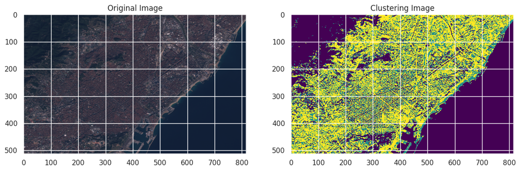

```python
plt.figure(figsize=(14,14))
plt.subplot(1,2,1),
plt.imshow(rgb)
plt.title('Original Image')
plt.subplot(1,2,2),
plt.imshow(label_img,cmap=viridis)
plt.title('Clustering Image')
plt.show()
```

## Color Quantization

Color Quantization is the process of reducing number of colors in an image. One reason to do so is to reduce the memory. Sometimes, some devices may have limitation such that it can produce only limited number of colors. In those cases also, color quantization is performed. Here we use k-means clustering for color quantization.

There is nothing new to be explained here. There are 3 features, say, R,G,B. So we need to reshape the image to an array of Mx3 size (M is number of pixels in image). And after the clustering, we apply centroid values (it is also R,G,B) to all pixels, such that resulting image will have specified number of colors. And again we need to reshape it back to the shape of original image.

```python
center = np.uint8(center)
```

```python
res = center[label.flatten()]
result_image = res.reshape((rgb.shape))
```

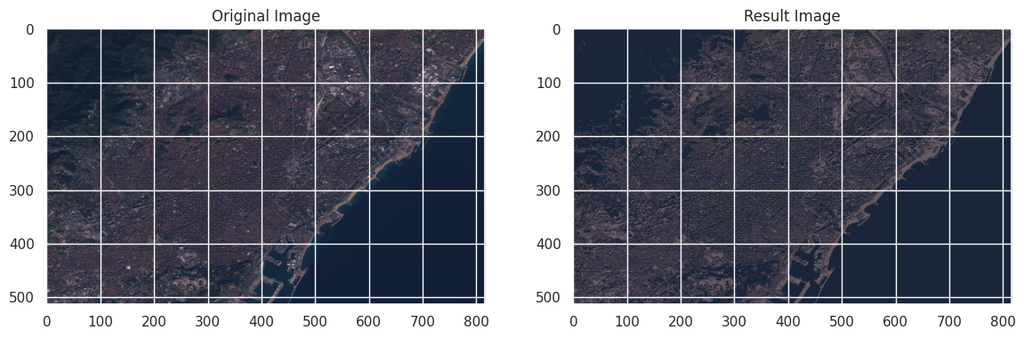

```python
plt.figure(figsize=(14,14))
plt.subplot(1,2,1),
plt.imshow(rgb)
plt.title('Original Image')
plt.subplot(1,2,2),
plt.imshow(result_image)
plt.title('Result Image')
plt.show()
```

## Clustering with Sklearn

to use Kmeans from SKlearn, let's use another image as an example.

```python
path_vine = '/content/drive/MyDrive/Datasets_CV/DJI_0366.JPG'
```

```python
with rasterio.open(path_vine) as src:
    img = src.read()
```

```python
img.shape
```

```
(3, 3000, 4000)
```

```python
img = img.transpose([1,2,0])
```

Let's plot a drone image over a viticulture:

```
(-0.5, 3999.5, 2999.5, -0.5)
```

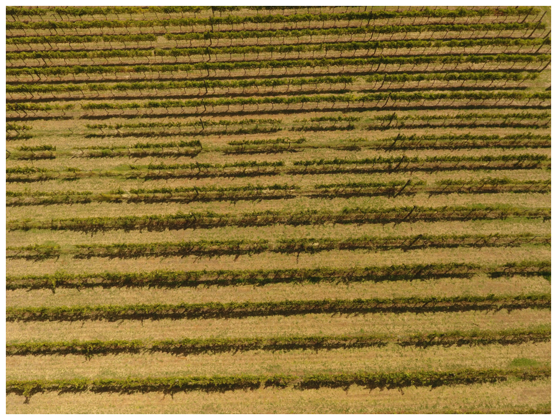

```python
plt.figure(figsize=[12,12])
plt.imshow(img)
plt.axis('off')
```

We followed practically the same procedure, reshape the image, setting the number of clusters to 3, obtaining the result of the clusters and reshape to the original value of the image:

```python
img_vectorized = img.reshape((-1,3))
```

```python
KMeans_pred = KMeans(n_clusters=3).fit_predict(img_vectorized)
```

```python
KMeans_pred = KMeans_pred.reshape((img.shape[0:2]))
```

As a result we have the image and three colors:

```python
dark2 = cm.get_cmap('Dark2', 3)
```

```
(-0.5, 3999.5, 2999.5, -0.5)
```

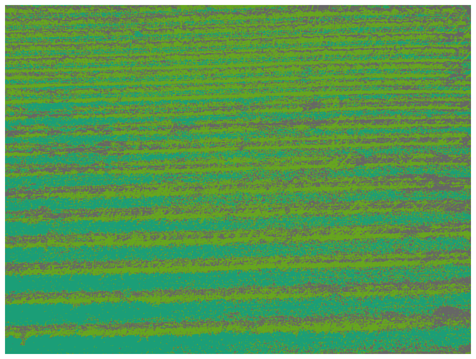

```python
plt.figure(figsize=[12,12])
plt.imshow(KMeans_pred,cmap=dark2)
plt.axis('off')
```

After observing the resulting image, we can binarize the image by separating the soil from the plants and shadows:

```python
binary_img = np.where(KMeans_pred==0,0,1)
```

```
(-0.5, 3999.5, 2999.5, -0.5)
```

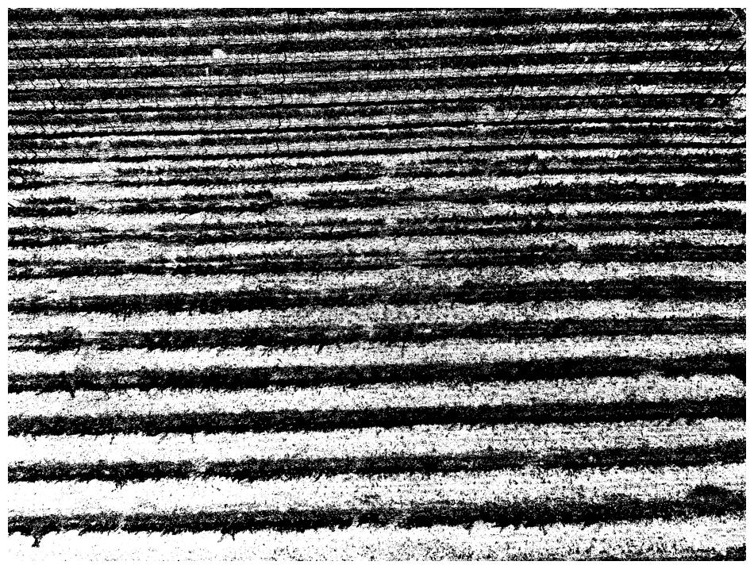

```python
plt.figure(figsize=[12,12])
plt.imshow(binary_img,cmap='Greys')
plt.axis('off')
```

## Change Detection with PCA and Kmeans

Automatic change detection in images of a region acquired at different times is one the most interesting topics of image processing. Such images are known as multi temporal images. Change detection involves the analysis of two multi temporal satellite images to find any changes that might have occurred between the two time stamps. It is one of the major utilization of remote sensing and finds application in a wide range of tasks like defence inspections, deforestation assessment, land use analysis, disaster assessment and monitoring many other environmental/man-made changes.

We will be outlining an unsupervised method for change detection in this blog post. It involves the automatic analysis of the change data, i.e. the difference image, constructed using the multi temporal images. A difference image is the pixel-by-pixel subtraction of the 2 images. Eigen vectors of pixel blocks from the difference image will then be extracted by Principal Component Analysis (PCA). Subsequently, a feature vector is constructed for each pixel in the difference image by projecting that pixel’s neighbourhood onto the Eigen vectors. The feature vector space, which is the collection of the feature vectors for all the pixels, upon clustering by K-means algorithm gives us two clusters – one representing pixels belonging to the changed class, and other representing pixels belonging to the unchanged class. Each pixel will belong to either of the clusters and hence a change map can be generated. So, the steps towards implementing this application are:

1 - difference image generation and Eigen vector space (EVS)

2 - building the feature vector space (FVS)

3 - clustering of the feature vector space and change map

For this example, let's choose an area that has undergone some visible changes in recent years: Egypt's new capital.

```python
AOI = ee.Geometry.Polygon(
        [[[31.442781230966744, 30.029336441993525],
          [31.442781230966744, 29.97641391019041],
          [31.538911602060494, 29.97641391019041],
          [31.538911602060494, 30.029336441993525]]])
```

We will select Sentinel 2 images from January 2016 and 2021

```python
startDateviz_before = ee.Date.fromYMD(2016,1,1);
endDateviz_before = ee.Date.fromYMD(2016,1,31);
startDateviz_after = ee.Date.fromYMD(2021,1,1);
endDateviz_after = ee.Date.fromYMD(2021,1,31);

collectionviz_before = ee.ImageCollection("COPERNICUS/S2_HARMONIZED").filterDate(startDateviz_before,endDateviz_before).filterBounds(AOI).filterMetadata('CLOUDY_PIXEL_PERCENTAGE', 'less_than', 1);
collectionviz_after = ee.ImageCollection("COPERNICUS/S2_HARMONIZED").filterDate(startDateviz_after,endDateviz_after).filterBounds(AOI).filterMetadata('CLOUDY_PIXEL_PERCENTAGE', 'less_than', 1);
```

Then we select the median mosaic of the existing images and set the parameters for visualization:

```python
S2_before = collectionviz_before.median().clip(AOI).divide(10000)
S2_after = collectionviz_after.median().clip(AOI).divide(10000)

vis_params = {'min': 0, 'max': 0.4, 'bands': ['B4', 'B3','B2']}
```

Here we define some basemaps to use in Folium:

```python
basemaps = {
    'Google Satellite': folium.TileLayer(
        tiles = 'https://mt1.google.com/vt/lyrs=s&x={x}&y={y}&z={z}',
        attr = 'Google',
        name = 'Google Satellite',
        overlay = True,
        control = True
    ),
    'Google Terrain': folium.TileLayer(
        tiles = 'https://mt1.google.com/vt/lyrs=p&x={x}&y={y}&z={z}',
        attr = 'Google',
        name = 'Google Terrain',
        overlay = True,
        control = True
    )}
```

The add_ee_layer function will make it easy to add vector and image layers to Folium:

```python
def add_ee_layer(self, ee_object, vis_params, name):

    try:
        # display ee.Image()
        if isinstance(ee_object, ee.image.Image):
            map_id_dict = ee.Image(ee_object).getMapId(vis_params)
            folium.raster_layers.TileLayer(
            tiles = map_id_dict['tile_fetcher'].url_format,
            attr = 'Google Earth Engine',
            name = name,
            overlay = True,
            control = True
            ).add_to(self)
        # display ee.ImageCollection()
        elif isinstance(ee_object, ee.imagecollection.ImageCollection):
            ee_object_new = ee_object.mosaic()
            map_id_dict = ee.Image(ee_object_new).getMapId(vis_params)
            folium.raster_layers.TileLayer(
            tiles = map_id_dict['tile_fetcher'].url_format,
            attr = 'Google Earth Engine',
            name = name,
            overlay = True,
            control = True
            ).add_to(self)
        # display ee.Geometry()
        elif isinstance(ee_object, ee.geometry.Geometry):
            folium.GeoJson(
            data = ee_object.getInfo(),
            name = name,
            overlay = True,
            control = True
        ).add_to(self)
        # display ee.FeatureCollection()
        elif isinstance(ee_object, ee.featurecollection.FeatureCollection):
            ee_object_new = ee.Image().paint(ee_object, 0, 2)
            map_id_dict = ee.Image(ee_object_new).getMapId(vis_params)
            folium.raster_layers.TileLayer(
            tiles = map_id_dict['tile_fetcher'].url_format,
            attr = 'Google Earth Engine',
            name = name,
            overlay = True,
            control = True
        ).add_to(self)

    except:
        print("Could not display {}".format(name))

# Add EE drawing method to folium.
folium.Map.add_ee_layer = add_ee_layer
```

Now we can plot the two images and compare them:

```python
my_map = folium.Map(location=AOI.centroid().coordinates().reverse().getInfo(), zoom_start=14)

# Add custom basemaps
basemaps['Google Terrain'].add_to(my_map)

# Add the elevation model to the map object.
my_map.add_ee_layer(S2_before, vis_params, 'New Cairo 2016')
my_map.add_ee_layer(S2_after, vis_params, 'New Cairo 2021')
my_map.add_child(folium.LayerControl())

# Display the map.
display(my_map)
```

[interactive chart not shown]

Let's now download them to Drive and import using the rasterio:

```python
image_before = S2_before.select(['B2','B3','B4','B5','B8']).reproject('EPSG:4326', None, 20)
image_after = S2_after.select(['B2','B3','B4','B5','B8']).reproject('EPSG:4326', None, 20)
```

```python
task = ee.batch.Export.image.toDrive(image=image_before,
                                         crs='EPSG:4326',
                                         scale=20,
                                         fileFormat='GeoTIFF',
                                         description='New_Cairo_2016' ,
                                         maxPixels=1e13,
                                         folder='Datasets',
                                         region= AOI)
```

```python
task.start()
```

```python
task2 = ee.batch.Export.image.toDrive(image=image_after,
                                         crs='EPSG:4326',
                                         scale=20,
                                         fileFormat='GeoTIFF',
                                         description='New_Cairo_2021' ,
                                         maxPixels=1e13,
                                         folder='Datasets',
                                         region= AOI)
```

```python
task2.start()
```

```python
path_before = '/content/drive/MyDrive/Datasets_CV/New_Cairo_2016.tif'
path_after= '/content/drive/MyDrive/Datasets_CV/New_Cairo_2021.tif'
```

```python
with rasterio.open(path_before) as src:
    im_before = src.read()
```

```python
with rasterio.open(path_after) as src:
    im_after = src.read()
```

We will perform the same procedure we always do when importing new images:

```python
im_before = im_before.transpose([1,2,0])
im_after = im_after.transpose([1,2,0])
```

```python
im_before = im_before*2*255
im_after = im_after*2*255
```

```python
im_before = im_before.astype('uint8')
im_after = im_after.astype('uint8')
```

Here, we are going to use the BGR to HSV conversion and use the intensity band to identify changes:

```python
red_b = im_before[:,:,2]
green_b = im_before[:,:,1]
blue_b = im_before[:,:,0]

red_a = im_after[:,:,2]
green_a = im_after[:,:,1]
blue_a = im_after[:,:,0]
```

```python
bgr_b = np.dstack((blue_b, green_b, red_b))
bgr_a = np.dstack((blue_a, green_a, red_a))
```

```python
nir_before = im_before[:,:,3]
nir_after = im_after[:,:,3]
```

```python
img_hsv_before = cv2.cvtColor(bgr_b, cv2.COLOR_BGR2HSV)
img_hsv_after = cv2.cvtColor(bgr_a, cv2.COLOR_BGR2HSV)
```

```python
img_value_before = img_hsv_before[:,:,2]
img_value_after = img_hsv_after[:,:,2]
```

Now we can compare the images representing the intensity:

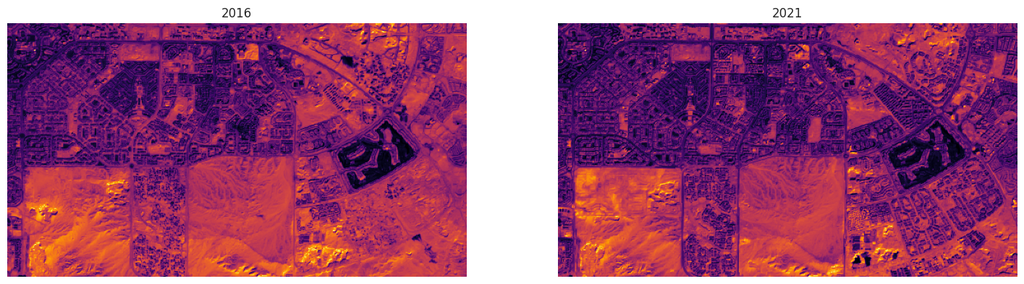

```python
plt.figure(figsize=(18,14))
plt.subplot(1,2,1),
plt.imshow(img_value_before, cmap='inferno')
plt.axis('off')
plt.title('2016')
plt.subplot(1,2,2),
plt.imshow(img_value_after, cmap='inferno')
plt.title('2021')
plt.axis('off')
plt.show()
```

Let's create some helper functions to accomplish the task. The complete code is at the following github: https://github.com/abhijeet3922/Change-Detection-in-Satellite-Imagery/blob/master/PCAKmeans.py

```python
def find_vector_set(diff_image, new_size):

    i = 0
    j = 0
    vector_set = np.zeros((int(new_size[0] * new_size[1] / 25), 25))

    while i < vector_set.shape[0]:
        while j < new_size[0]:
            k = 0
            while k < new_size[1]:
                block   = diff_image[j:j+5, k:k+5]
                #print(i,j,k,block.shape)
                feature = block.ravel()
                vector_set[i, :] = feature
                k = k + 5
            j = j + 5
        i = i + 1


    mean_vec   = np.mean(vector_set, axis = 0)
    vector_set = vector_set - mean_vec

    return vector_set, mean_vec
```

```python
def find_FVS(EVS, diff_image, mean_vec, new):

    i = 2
    feature_vector_set = []

    while i < new[0] - 2:
        j = 2
        while j < new[1] - 2:
            block = diff_image[i-2:i+3, j-2:j+3]
            feature = block.flatten()
            feature_vector_set.append(feature)
            j = j+1
        i = i+1

    FVS = np.dot(feature_vector_set, EVS)
    FVS = FVS - mean_vec
    return FVS
```

```python
def clustering(FVS, components, new):

    kmeans = KMeans(components, verbose = 0)
    kmeans.fit(FVS)
    output = kmeans.predict(FVS)
    count  = Counter(output)

    least_index = min(count, key = count.get)
    change_map  = np.reshape(output,(new[0] - 4, new[1] - 4))

    return least_index, change_map
```

First, let's resize the image to a size multiple of 5:

```python
new_size = np.asarray(img_value_before.shape) / 5
new_size = new_size.astype(int) * 5
```

```python
im_after = resize(img_value_after, (new_size))
im_before = resize(img_value_before, (new_size))
```

The conversion changed the range of values to 0 to 1. Let's return to the range from 0 to 255.

```python
im_after = im_after*255
im_before = im_before*255
```

So we can create the difference image and then convert it to int16.

```python
diff_image = abs(im_after - im_before)
```

```python
diff_image = diff_image.astype('int16')
```

In this method, we take non-overlapping blocks of size 5 x 5 from the difference image and flatten them into row vectors:

```python
vector_set, mean_vec = find_vector_set(diff_image, new_size)
```

PCA is then applied on this vector set to get the Eigen vector space. The Eigen vector space will be a 25 x 25 matrix; its each column is an Eigen vector of 25 dimensions.In Python, from sklearn.decomposition, we can simply import the PCA module and use it to perform PCA on vector_set variable to get the variable EVS:

```python
pca = PCA()
pca.fit(vector_set)
```

```
PCA()
```

```python
EVS = pca.components_
```

```python
FVS = find_FVS(EVS, diff_image, mean_vec, new_size)
```

The feature vectors for the pixels carry information whether the pixels have characteristics of a changed pixel or an unchanged one. Having constructed the feature vector space, we now need to cluster it so that the pixels can be grouped into two disjoint classes. We will be using the K-means algorithm to do that. Thus each pixel will get assigned to a cluster in such a way that the distance between the cluster’s mean vector and the pixel’s feature vector is the least. Each pixel gets a label from 1 to K, which denotes the cluster number that they belong to.

```python
components = 3
least_index, change_map = clustering(FVS, components, new_size)
```

Thus the argument components in clustering() will be 3. Remember, even though we have to do divide the pixels into 2 categories, we have chosen K = 3, instead of 2. Now how do we decide which of these clusters contains the pixels that belong to the changed class? It can be postulated that the cluster which contains the lowest number of pixels (denoted by variable least_index) is the cluster denoting the changed class, since the background remains more or less the same in satellite images and the changes occurred are comparatively less. Also, the mean of this cluster will be the highest. The reason behind the highest value of mean for that cluster is that the values of the difference image pixels in a region where some changes have occurred are higher than the values of pixels in the regions where there is no change.

Thus, in conclusion, the cluster with the lowest number of pixels, and also the highest mean is the cluster belonging to the changed class.

With this information, we will now build a change map – a binary image to show the output of change detection. We have chosen to keep the background black and will show the changes in white, i.e., intensity value of those pixels will be 255. You can do the reverse as well.

```python
change_map[change_map == least_index] = 255
change_map[change_map != 255] = 0
change_map = change_map.astype(np.uint8)
```

Finally, let's erode the image to filter out some noise:

```python
kernel = np.asarray(((0,0,1,0,0),
                     (0,1,1,1,0),
                     (1,1,1,1,1),
                     (0,1,1,1,0),
                     (0,0,1,0,0)), dtype=np.uint8)
```

```python
cleanChangeMap = cv2.erode(change_map,kernel)
```

Finally, we can present the difference image and the change map of the study region:

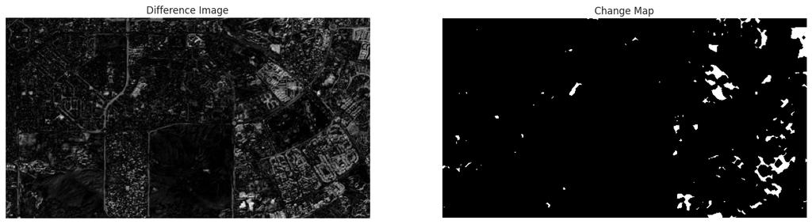

```python
plt.figure(figsize=(18,14))
plt.subplot(1,2,1),
plt.imshow(diff_image, cmap='Greys_r')
plt.axis('off')
plt.title('Difference Image')
plt.subplot(1,2,2),
plt.imshow(cleanChangeMap, cmap='Greys_r')
plt.title('Change Map')
plt.axis('off')
plt.show()
```

## Unsupervised Segmentation

In digital image processing and computer vision, image segmentation is the process of partitioning a digital image into multiple segments (sets of pixels, also known as image objects). The goal of segmentation is to simplify and/or change the representation of an image into something that is more meaningful and easier to analyze. Image segmentation is typically used to locate objects and boundaries (lines, curves, etc.) in images. More precisely, image segmentation is the process of assigning a label to every pixel in an image such that pixels with the same label share certain characteristics.

The result of image segmentation is a set of segments that collectively cover the entire image, or a set of contours extracted from the image (see edge detection). Each of the pixels in a region are similar with respect to some characteristic or computed property, such as color, intensity, or texture. Adjacent regions are significantly different color respect to the same characteristic(s). When applied to a stack of images, typical in medical imaging, the resulting contours after image segmentation can be used to create 3D reconstructions with the help of interpolation algorithms like marching cubes.

Unsupervised segmentation requires no prior knowledge. Consider an image that is so large that it is not feasible to consider all pixels simultaneously. So in such cases, Unsupervised segmentation can breakdown the image into several sub-regions, so instead of millions of pixels, you have tens to hundreds of regions.

```python
from skimage.segmentation import felzenszwalb, slic, quickshift, watershed
from skimage.segmentation import mark_boundaries
from skimage.util import img_as_float
from skimage.filters import sobel
from skimage.color import rgb2gray
from skimage import color
```

Let's prepare our RGB image, converting to float:

```python
img = img_as_float(rgb)
```

## Felzenszwalb’s efficient graph based segmentation

This fast 2D image segmentation algorithm, proposed in 1 is popular in the computer vision community. The algorithm has a single scale parameter that influences the segment size. The actual size and number of segments can vary greatly, depending on local contrast.

```python
segments_fz = felzenszwalb(img, scale=100, sigma=0.5, min_size=50)
```

Let's see how the segments were divided:

```
(-0.5, 816.5, 512.5, -0.5)
```

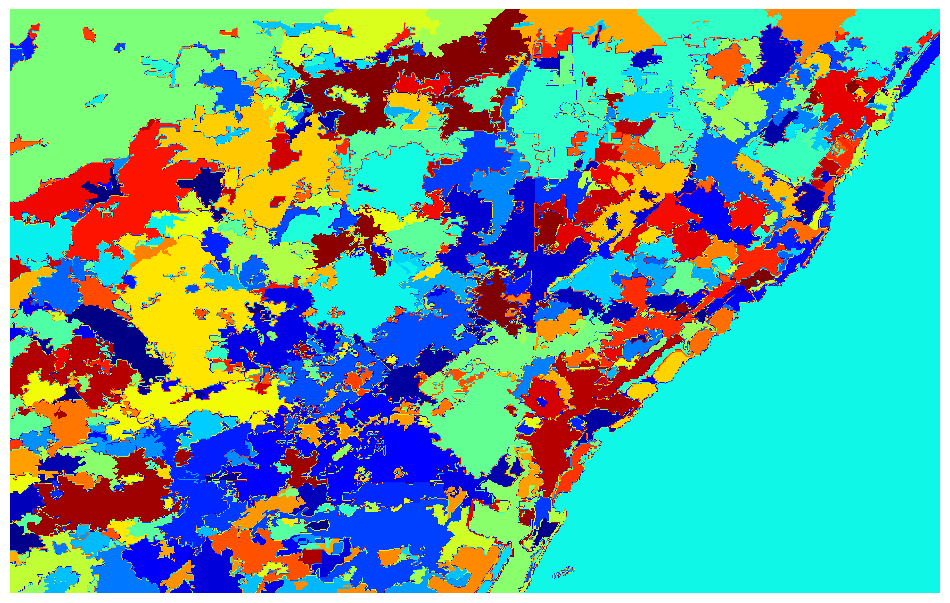

```python
vals = np.linspace(0,1,250)
np.random.shuffle(vals)
cmap = plt.cm.colors.ListedColormap(plt.cm.jet(vals))
plt.figure(figsize=[12,12])
plt.imshow(segments_fz, cmap=cmap )
plt.axis('off')
```

We can also overlap the outlines over the original image:

```
(-0.5, 816.5, 512.5, -0.5)
```

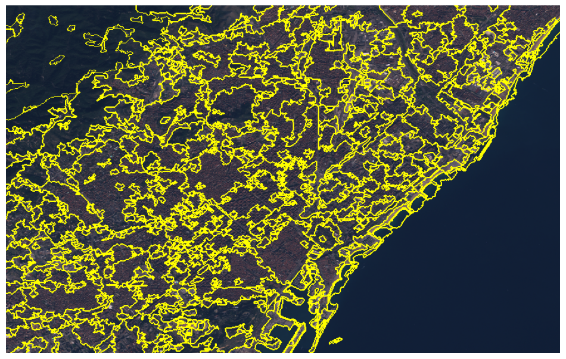

```python
plt.figure(figsize=[12,12])
plt.imshow(mark_boundaries(img, segments_fz))
plt.axis('off')
```

## SLIC - K-Means based image segmentation

This algorithm simply performs K-means in the 5d space of color information and image location and is therefore closely related to quickshift. As the clustering method is simpler, it is very efficient. It is essential for this algorithm to work in Lab color space to obtain good results. The algorithm quickly gained momentum and is now widely used. See 3 for details. The compactness parameter trades off color-similarity and proximity, as in the case of Quickshift, while n_segments chooses the number of centers for kmeans.

```python
segments_slic = slic(img, n_segments=250, compactness=10, sigma=1, start_label=1)
```

```
(-0.5, 816.5, 512.5, -0.5)
```

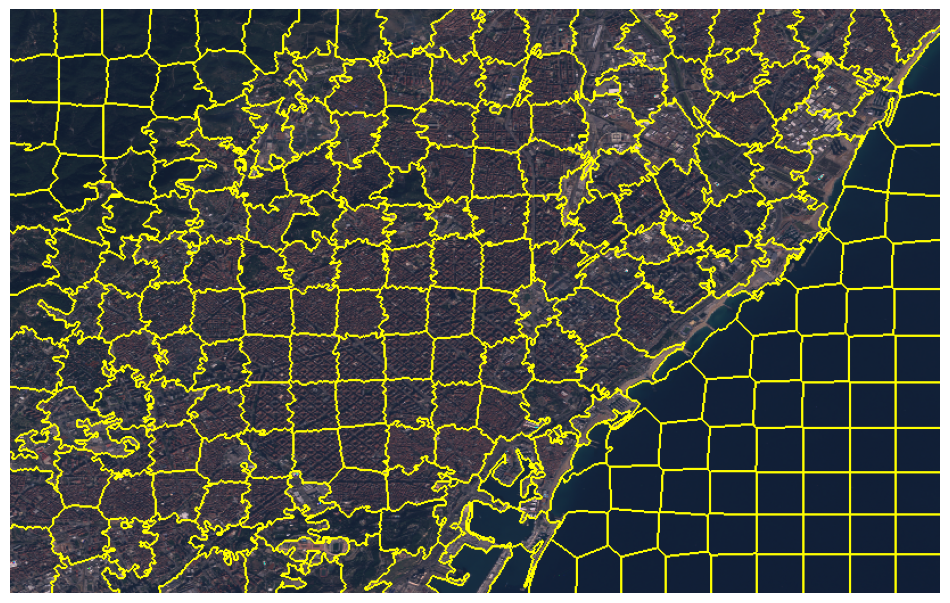

```python
plt.figure(figsize=[12,12])
plt.imshow(mark_boundaries(img, segments_slic))
plt.axis('off')
```

Let's create an image representing the average value of the RGB channels per segment:

```
(-0.5, 816.5, 512.5, -0.5)
```

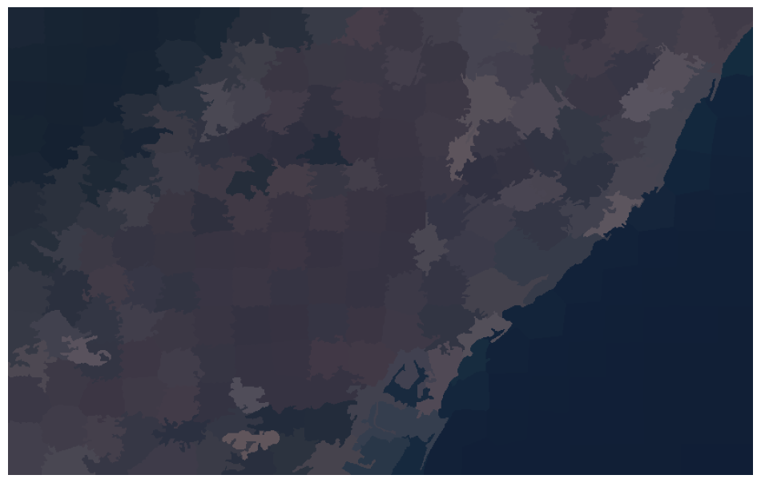

```python
LabelsAve = color.label2rgb(segments_slic, img, kind='avg')
plt.figure(figsize=[12,12])
plt.imshow(LabelsAve)
plt.axis('off')
```

## Quickshift image segmentation

Quickshift is a relatively recent 2D image segmentation algorithm, based on an approximation of kernelized mean-shift. Therefore it belongs to the family of local mode-seeking algorithms and is applied to the 5D space consisting of color information and image location 2.

One of the benefits of quickshift is that it actually computes a hierarchical segmentation on multiple scales simultaneously.

Quickshift has two main parameters: sigma controls the scale of the local density approximation, max_dist selects a level in the hierarchical segmentation that is produced. There is also a trade-off between distance in color-space and distance in image-space, given by ratio.

```python
segments_quick = quickshift(img, kernel_size=3, max_dist=6, ratio=0.5)
```

```
(-0.5, 816.5, 512.5, -0.5)
```

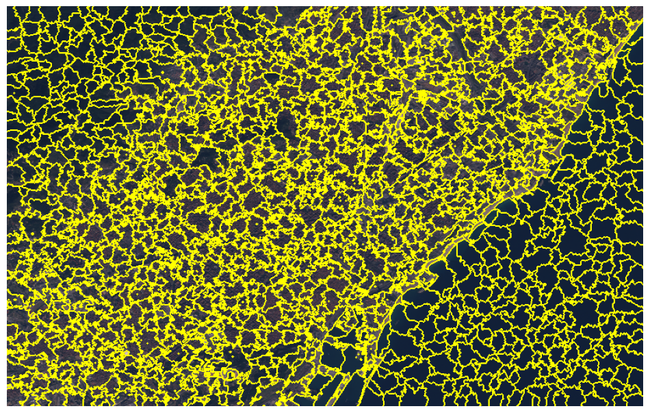

```python
plt.figure(figsize=[12,12])
plt.imshow(mark_boundaries(img, segments_quick))
plt.axis('off')
```

## Compact watershed segmentation of gradient images

Instead of taking a color image as input, watershed requires a grayscale gradient image, where bright pixels denote a boundary between regions. The algorithm views the image as a landscape, with bright pixels forming high peaks. This landscape is then flooded from the given markers, until separate flood basins meet at the peaks. Each distinct basin then forms a different image segment. 4

As with SLIC, there is an additional compactness argument that makes it harder for markers to flood faraway pixels. This makes the watershed regions more regularly shaped

```python
gradient = sobel(rgb2gray(img))
segments_watershed = watershed(gradient, markers=250, compactness=0.001)
```

```
(-0.5, 816.5, 512.5, -0.5)
```

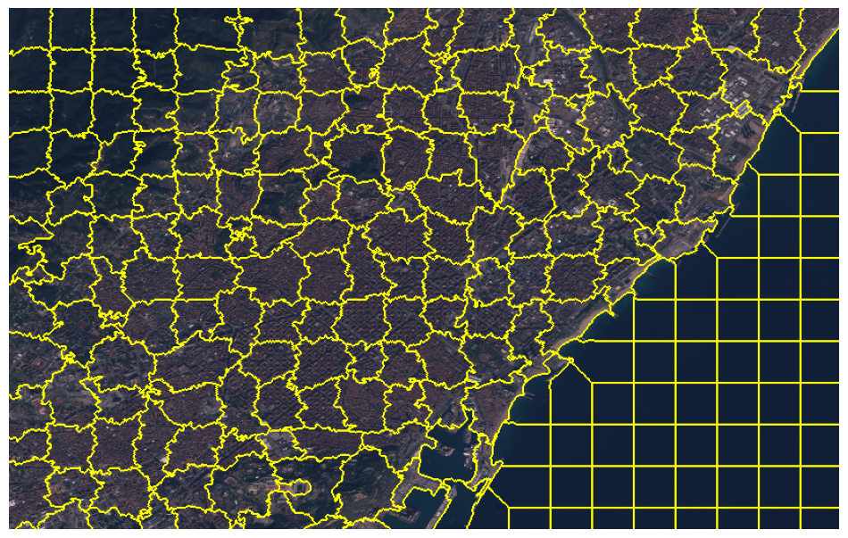

```python
plt.figure(figsize=[12,12])
plt.imshow(mark_boundaries(img, segments_watershed))
plt.axis('off')
```

You can also convert the segments to vectors and save it as a SHAPEFILE file for example:

```python
segments_watershed = segments_watershed.astype('uint16')
```

Let's import the "features" function from the rasterio and the geopandas and shapely libraries

```python
from rasterio import features
from shapely.geometry import shape
import geopandas as gpd
import shapely
```

First we perform the image to vector conversion:

```python
src_barc = rasterio.open(path_barcelona)
```

```python
find_shapes = features.shapes(segments_watershed, transform=src_barc.transform)
```

Then we get the coordinates of each vector:

```python
polygons = [shapely.geometry.Polygon(shape[0]["coordinates"][0]) for shape in find_shapes]
```

We created a geodataframe and set the crs:

```python
crs = {'init': 'epsg:4326'}
my_gdf = gpd.GeoDataFrame(crs=crs, geometry=polygons)
```

And finally we save the file on the drive:

```python
my_gdf.to_file("/content/Segments.shp", driver='ESRI Shapefile')
```

## Apply maskSLIC

The maskSLIC method is an extension of the SLIC method for the generation of superpixels in a region of interest. maskSLIC is able to overcome border problems that affects SLIC method, particularely in case of irregular mask.

Let's use the image, the image of a viticulture and the mask of the region with valid pixels:

```python
path_vine2 = '/content/drive/MyDrive/Datasets_CV/Drone_img.tif'
```

```python
src = rasterio.open(path_vine2)
img2 = src.read()
```

```python
img2 = img2.transpose([1,2,0])
```

```python
img2 = img2.astype('uint8')
```

```
(-0.5, 3793.5, 2270.5, -0.5)
```

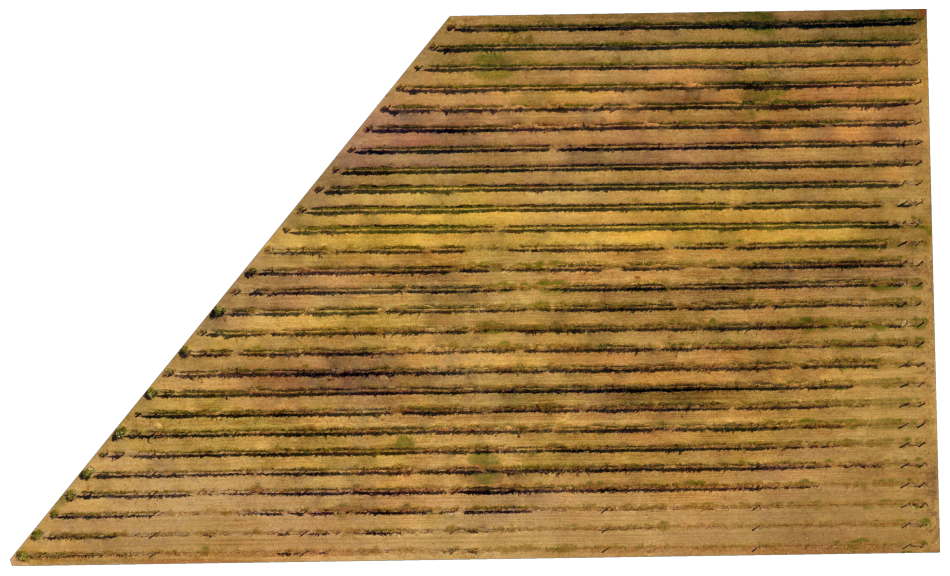

```python
plt.figure(figsize=[12,12])
plt.imshow(img2)
plt.axis('off')
```

```
(-0.5, 3793.5, 2270.5, -0.5)
```

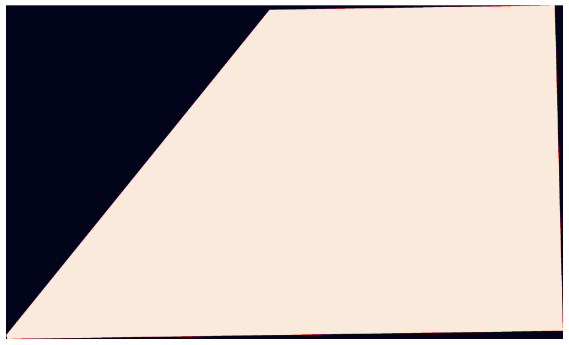

```python
plt.figure(figsize=[12,12])
plt.imshow(img2[:,:,3])
plt.axis('off')
```

We apply the SLIC setting the mask and segmentation occurs only in the valid region:

```python
mask = img2[:,:,3]
```

```python
img2 = img2[:,:,0:3]
```

```python
img2_float = img_as_float(img2)
```

```python
m_slic = slic(img2_float, n_segments=500, mask=mask, start_label=1)
```

```
(-0.5, 3793.5, 2270.5, -0.5)
```

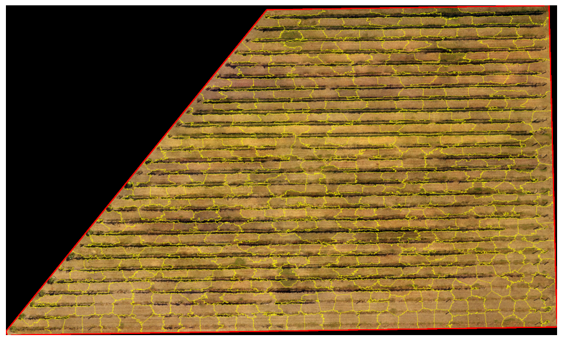

```python
plt.figure(figsize=[12,12])
plt.imshow(mark_boundaries(img2, m_slic))
plt.contour(mask, colors='red', linewidths=1)
plt.axis('off')
```

References:

https://www.analyticsvidhya.com/blog/2016/11/an-introduction-to-clustering-and-different-methods-of-clustering/

https://www.kdnuggets.com/2019/08/introduction-image-segmentation-k-means-clustering.html

https://docs.opencv.org/4.5.2/d1/d5c/tutorial_py_kmeans_opencv.html

https://en.wikipedia.org/wiki/Image_segmentation

https://docs.opencv.org/master/d3/db4/tutorial_py_watershed.html

https://towardsdatascience.com/image-segmentation-using-pythons-scikit-image-module-533a61ecc980

https://scikit-image.org/docs/stable/auto_examples/segmentation/plot_segmentations.html

https://scikit-image.org/docs/dev/auto_examples/segmentation/plot_mask_slic.html

https://towardsdatascience.com/principal-component-analysis-in-depth-understanding-through-image-visualization-892922f77d9f

https://docs.opencv.org/3.4/d1/dee/tutorial_introduction_to_pca.html

https://towardsdatascience.com/comprehensive-guide-to-satellite-imagery-analysis-using-python-1b4153bad2a

https://github.com/abhijeet3922/Change-Detection-in-Satellite-Imagery/blob/master/PCAKmeans.py

https://appliedmachinelearning.blog/2017/11/25/unsupervised-changed-detection-in-multi-temporal-satellite-images-using-pca-k-means-python-code/